# Statistics Analysis Homework 1

2015-26042 Hyunghun Cho

Friday, September 09, 2016

This is an exercise from OpenIntro Statistics https://www.openintro.org/stat/.

Firstly, I solved the exercises from **Introduction to data**: http://htmlpreview.github.io/?https://github.com/andrewpbray/oiLabs-base-R/blob/master/intro_to_data/intro_to_data.html

```r
source("http://www.openintro.org/stat/data/cdc.R")
names(cdc)
```

```
## [1] "genhlth"  "exerany"  "hlthplan" "smoke100" "height"   "weight"
## [7] "wtdesire" "age"      "gender"
```

```r
head(cdc)
```

```
##     genhlth exerany hlthplan smoke100 height weight wtdesire age gender
## 1      good       0        1        0     70    175      175  77      m
## 2      good       0        1        1     64    125      115  33      f
## 3      good       1        1        1     60    105      105  49      f
## 4      good       1        1        0     66    132      124  42      f
## 5 very good       0        1        0     61    150      130  55      f
## 6 very good       1        1        0     64    114      114  55      f
```

```r
tail(cdc)
```

```
##         genhlth exerany hlthplan smoke100 height weight wtdesire age
## 19995      good       0        1        1     69    224      224  73
## 19996      good       1        1        0     66    215      140  23
## 19997 excellent       0        1        0     73    200      185  35
## 19998      poor       0        1        0     65    216      150  57
## 19999      good       1        1        0     67    165      165  81
## 20000      good       1        1        1     69    170      165  83
##       gender
## 19995      m
## 19996      f
## 19997      m
## 19998      f
## 19999      f
## 20000      m
```

**Exercise 1 Answer** There is 20000 cases for each nine variables like follows: genhlth exerany hlthplan smoke100 height weight wtdesire age gender Each variables has following data types: categorical discrete discrete discrete discrete discrete discrete discrete categorical

```r
str(cdc)
```

```
## 'data.frame':    20000 obs. of  9 variables:
##  $ genhlth : Factor w/ 5 levels "excellent","very good",..: 3 3 3 3 2 2 2 2 3 3 ...
##  $ exerany : num  0 0 1 1 0 1 1 0 0 1 ...
##  $ hlthplan: num  1 1 1 1 1 1 1 1 1 1 ...
##  $ smoke100: num  0 1 1 0 0 0 0 0 1 0 ...
##  $ height  : num  70 64 60 66 61 64 71 67 65 70 ...
##  $ weight  : int  175 125 105 132 150 114 194 170 150 180 ...
##  $ wtdesire: int  175 115 105 124 130 114 185 160 130 170 ...
##  $ age     : int  77 33 49 42 55 55 31 45 27 44 ...
##  $ gender  : Factor w/ 2 levels "m","f": 1 2 2 2 2 2 1 1 2 1 ...
```

**Exercise 2 Answer**

```
##    Min. 1st Qu.  Median    Mean 3rd Qu.    Max.
##   48.00   64.00   67.00   67.18   70.00   93.00
```

```
##    Min. 1st Qu.  Median    Mean 3rd Qu.    Max.
##   18.00   31.00   43.00   45.07   57.00   99.00
```

```
## [1] 6
```

```
## [1] 26
```

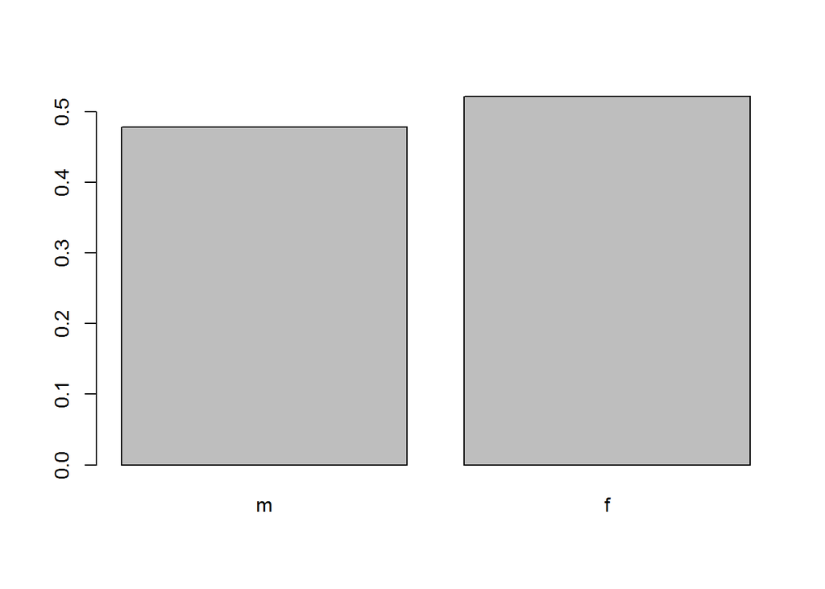

```
##    m
## 9569
```

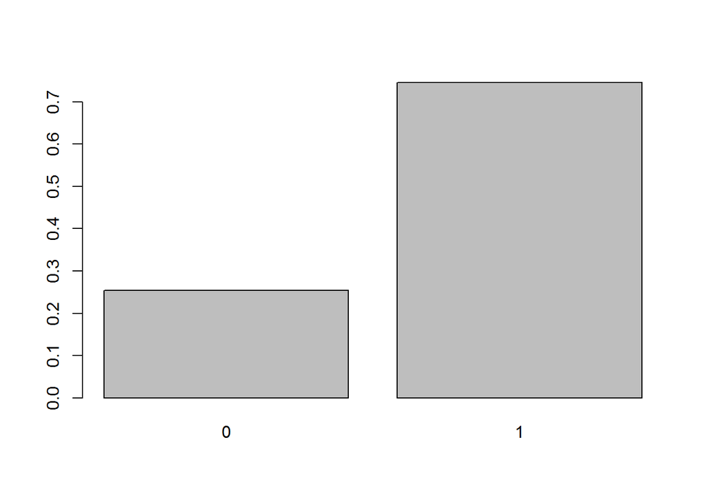

**Exercise 3 Answer** The below plot reveals that male has more smoking habits than female.

```
##
##        0    1
##   m 4547 5022
##   f 6012 4419
```

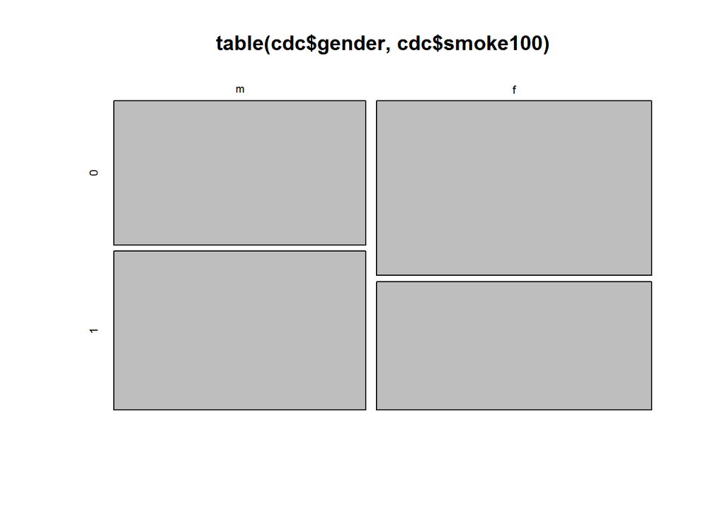

**Exercise 4 Answer**

```r
under23_and_smoke <- subset(cdc, cdc$smoke100 == 1 & cdc$age > 23)
summary(under23_and_smoke)
```

```
##       genhlth        exerany          hlthplan         smoke100
##  excellent:1635   Min.   :0.0000   Min.   :0.0000   Min.   :1
##  very good:2913   1st Qu.:0.0000   1st Qu.:1.0000   1st Qu.:1
##  good     :2642   Median :1.0000   Median :1.0000   Median :1
##  fair     :1044   Mean   :0.7236   Mean   :0.8764   Mean   :1
##  poor     : 436   3rd Qu.:1.0000   3rd Qu.:1.0000   3rd Qu.:1
##                   Max.   :1.0000   Max.   :1.0000   Max.   :1
##      height         weight         wtdesire          age        gender
##  Min.   :48.0   Min.   : 68.0   Min.   : 68.0   Min.   :24.00   m:4633
##  1st Qu.:64.0   1st Qu.:145.0   1st Qu.:130.0   1st Qu.:37.00   f:4037
##  Median :67.0   Median :170.0   Median :155.0   Median :47.00
##  Mean   :67.5   Mean   :173.1   Mean   :157.6   Mean   :49.38
##  3rd Qu.:71.0   3rd Qu.:195.0   3rd Qu.:180.0   3rd Qu.:61.00
##  Max.   :81.0   Max.   :495.0   Max.   :601.0   Max.   :99.00
```

**Exercise 5 Answer** Below boxplot shows a trend which the who is well has less BMI Index.  
But, the smokers and non smokers have no significant differences to BMI Index. I thought that smokers may have bad health conditions, but this is a wrong assumption.

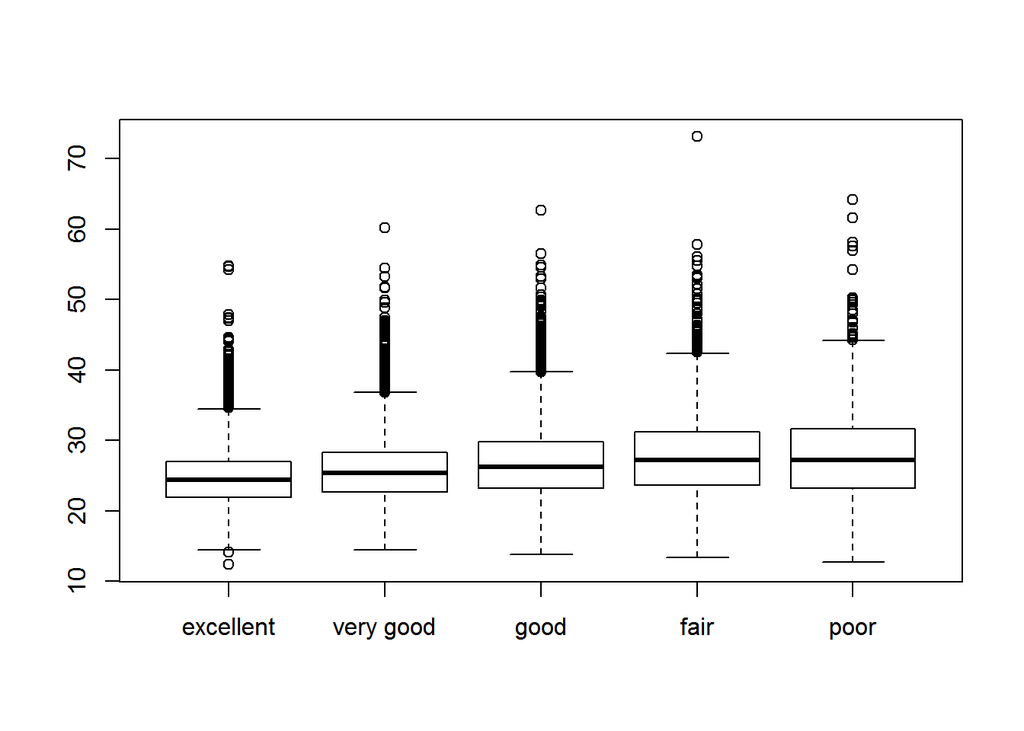

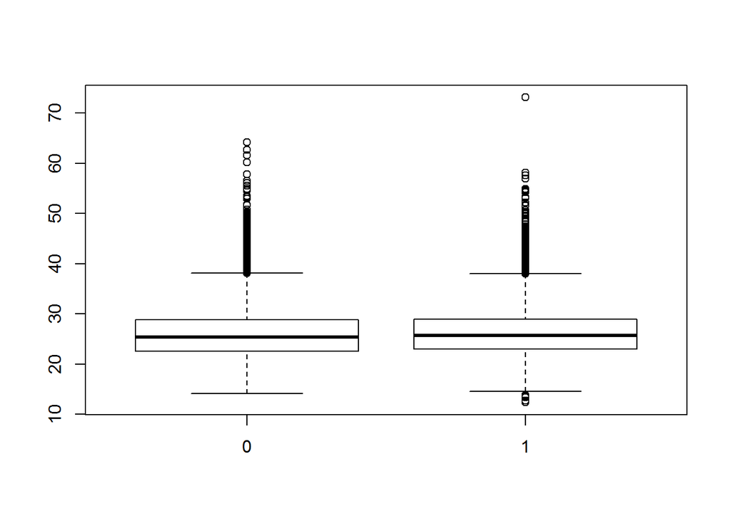

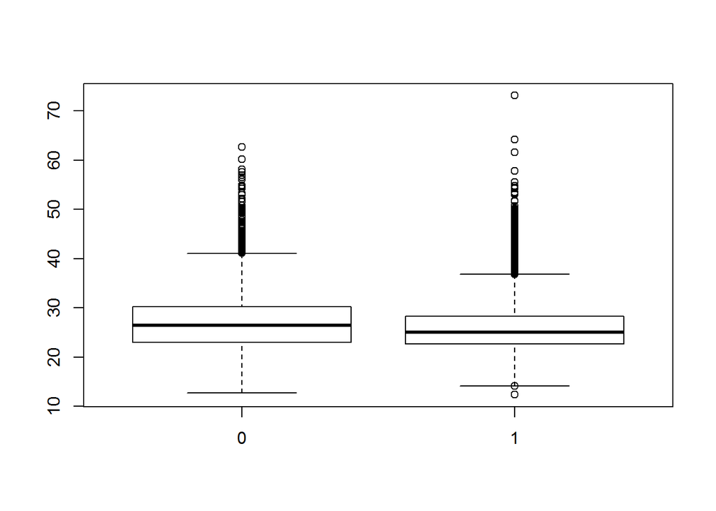

It’s time to solve the questions in On Your Own.

**On Your Own 1 Answer** Below figure shows that there is a positive relationship between weight and desired weight.

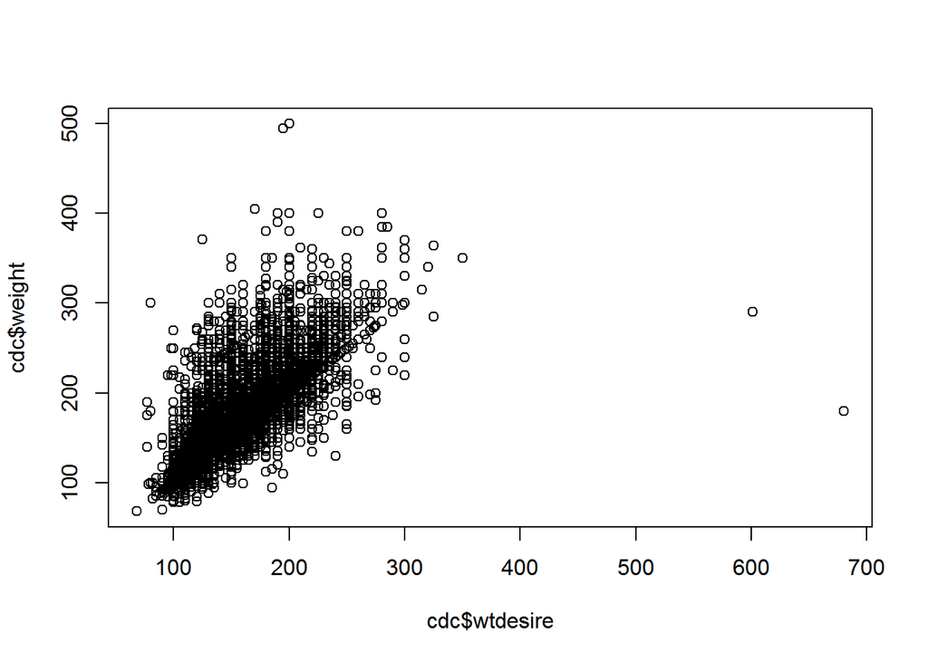

**On Your Own 2 Answer**

```r
wdiff <- cdc$weight - cdc$wtdesire
```

**On Your Own 3 Answer** wdiff is 0 if a person’s desired weight is same as his(her) current weight. If it is positive, it means that he(she) want to lose his(her) weight. Otherwise he(she) want to put weight on.

```r
print (typeof(wdiff))
```

```
## [1] "integer"
```

**On Your Own 4 Answer** Almost people want to lose their weight a little bit. Also, there are outliers who want to lose or to put on many weights.

```
##    Min. 1st Qu.  Median    Mean 3rd Qu.    Max.
## -500.00    0.00   10.00   14.59   21.00  300.00
```

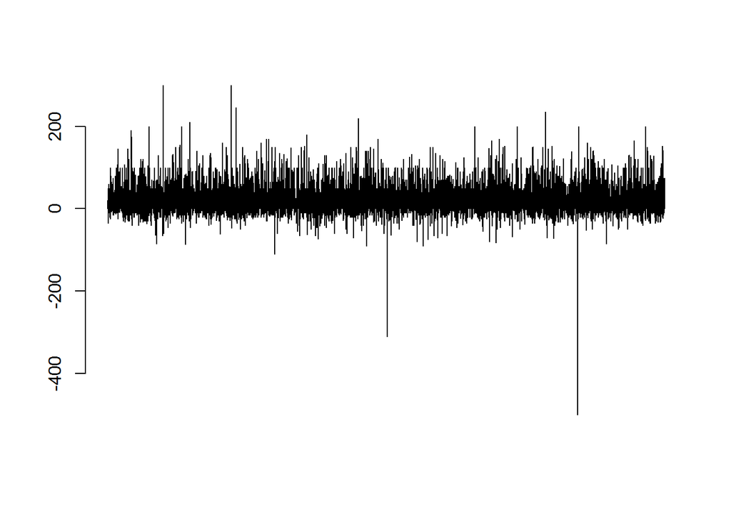

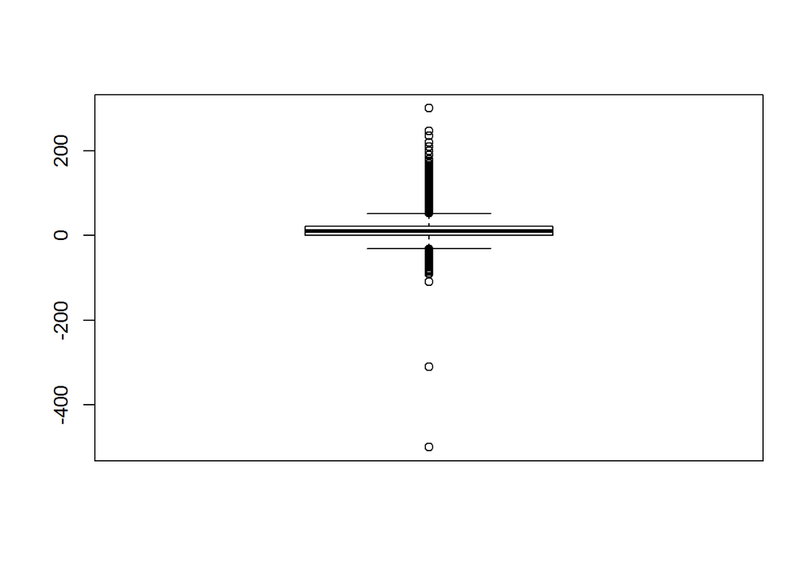

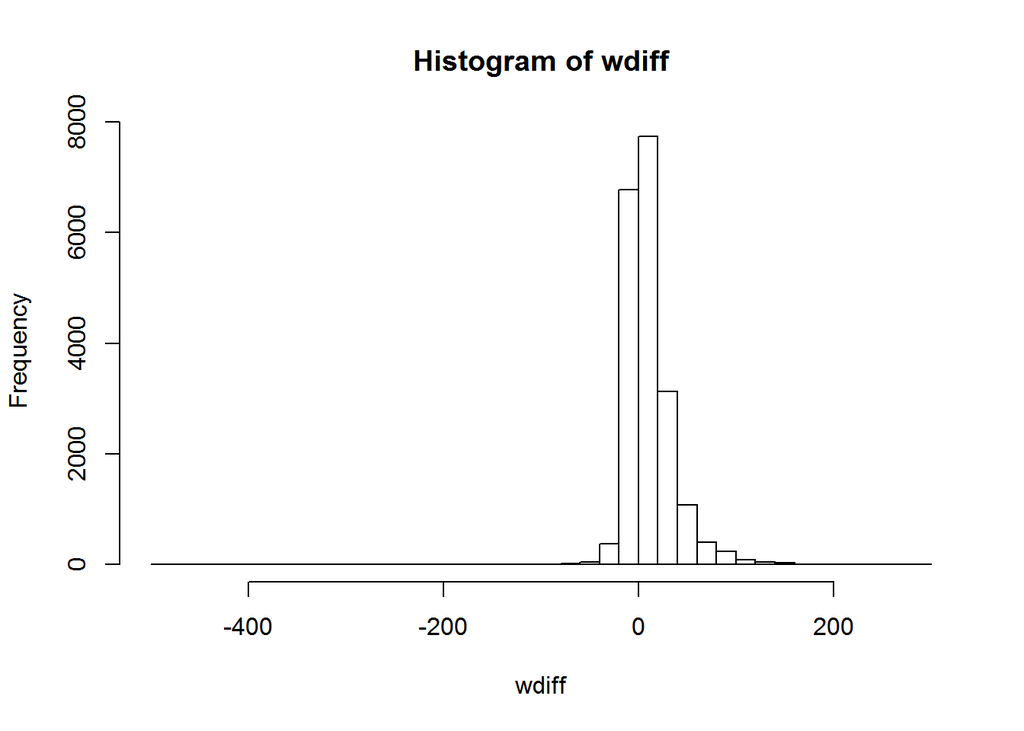

**On Your Own 5 Answer** Men and women has no significant differences to view about their weight.

```
##       genhlth        exerany          hlthplan         smoke100
##  excellent:2298   Min.   :0.0000   Min.   :0.0000   Min.   :0.0000
##  very good:3382   1st Qu.:1.0000   1st Qu.:1.0000   1st Qu.:0.0000
##  good     :2722   Median :1.0000   Median :1.0000   Median :1.0000
##  fair     : 884   Mean   :0.7754   Mean   :0.8688   Mean   :0.5248
##  poor     : 283   3rd Qu.:1.0000   3rd Qu.:1.0000   3rd Qu.:1.0000
##                   Max.   :1.0000   Max.   :1.0000   Max.   :1.0000
##      height          weight         wtdesire          age        gender
##  Min.   :49.00   Min.   : 78.0   Min.   : 77.0   Min.   :18.00   m:9569
##  1st Qu.:68.00   1st Qu.:165.0   1st Qu.:160.0   1st Qu.:31.00   f:   0
##  Median :70.00   Median :185.0   Median :175.0   Median :42.00
##  Mean   :70.25   Mean   :189.3   Mean   :178.6   Mean   :44.27
##  3rd Qu.:72.00   3rd Qu.:210.0   3rd Qu.:190.0   3rd Qu.:55.00
##  Max.   :93.00   Max.   :500.0   Max.   :680.0   Max.   :94.00
```

```
##       genhlth        exerany          hlthplan         smoke100
##  excellent:2359   Min.   :0.0000   Min.   :0.0000   Min.   :0.0000
##  very good:3590   1st Qu.:0.0000   1st Qu.:1.0000   1st Qu.:0.0000
##  good     :2953   Median :1.0000   Median :1.0000   Median :0.0000
##  fair     :1135   Mean   :0.7184   Mean   :0.8783   Mean   :0.4236
##  poor     : 394   3rd Qu.:1.0000   3rd Qu.:1.0000   3rd Qu.:1.0000
##                   Max.   :1.0000   Max.   :1.0000   Max.   :1.0000
##      height          weight         wtdesire          age       gender
##  Min.   :48.00   Min.   : 68.0   Min.   : 68.0   Min.   :18.0   m:    0
##  1st Qu.:62.00   1st Qu.:128.0   1st Qu.:120.0   1st Qu.:32.0   f:10431
##  Median :64.00   Median :145.0   Median :130.0   Median :43.0
##  Mean   :64.37   Mean   :151.7   Mean   :133.5   Mean   :45.8
##  3rd Qu.:66.00   3rd Qu.:170.0   3rd Qu.:145.0   3rd Qu.:58.0
##  Max.   :78.00   Max.   :495.0   Max.   :350.0   Max.   :99.0
```

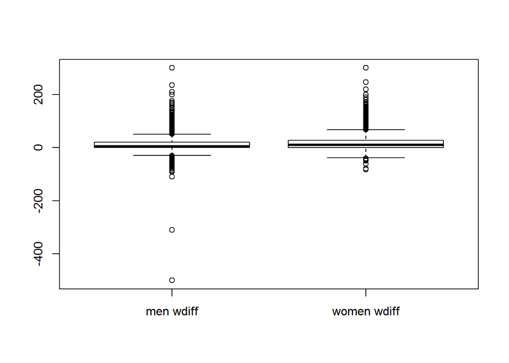

**On Your Own 5 Answer**

```r
weight.mean <- mean(cdc$weight)
weight.sd <- sd(cdc$weight)
print (paste(c(weight.mean, weight.sd), collapse=', '))
```

```
## [1] "169.68295, 40.08096996712"
```

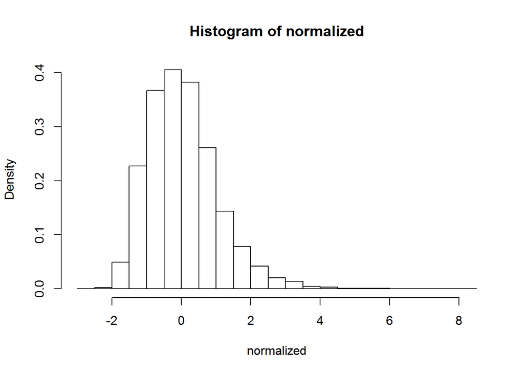

```r
normalized <- (cdc$weight - weight.mean)/weight.sd
hist(normalized, freq = FALSE)
```